# The inter-continental population dynamics of Neisseria gonorrhoeae

This page describes a subset of the analyses for the paper *The inter-continental population dynamics of Neisseria gonorrhoeae*. The aim of this project was to investigate the global transmission dynamics of *Neisseria gonorrhoeae* in recent time. To do so we collected a globally diverse set of sequences. The main locations are from Australia (n=2203), Norway (n=1724), the USA (n=2372), but multiple other countries are represented in the remaining sequences (n=3434).

### [Transmission lineages and metadata exploration](https://magnunos.shinyapps.io/LineageHomology_Explorer)

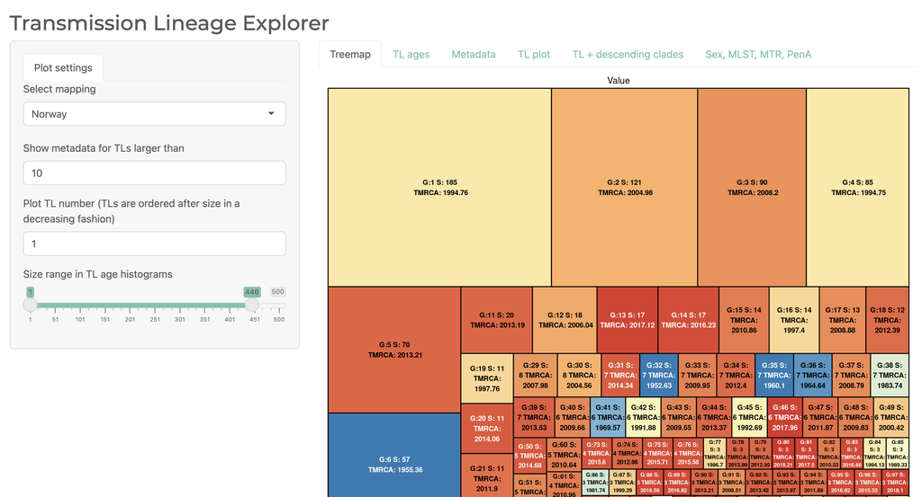

The R-shiny app above displays the estimated [transmission lineages](https://www.science.org/doi/10.1126/science.abf2946), their size, the estimated time they arrived in the focal location. It can be used to explore single transmission lineages, and the metadata of the observed sequences from those lineages. To estimate the transmission lineages we have used the R-package LineageHomology.

### Transmission lineage statistics

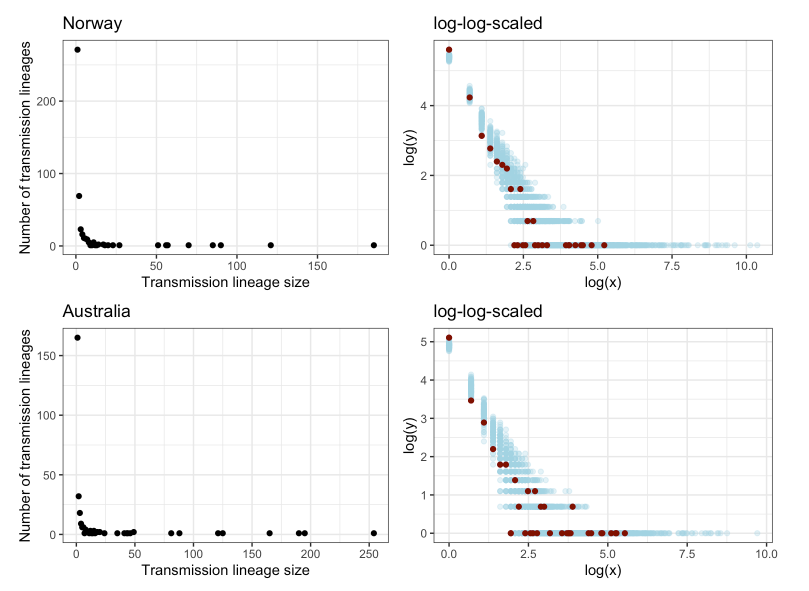

Here we look into the number of local cases that can be explained by the largest transmission lineages and how many can be explained by singletons. Additionally we look at the distribution of transmission lineage sizes.

### Import, export and local transmission analyses

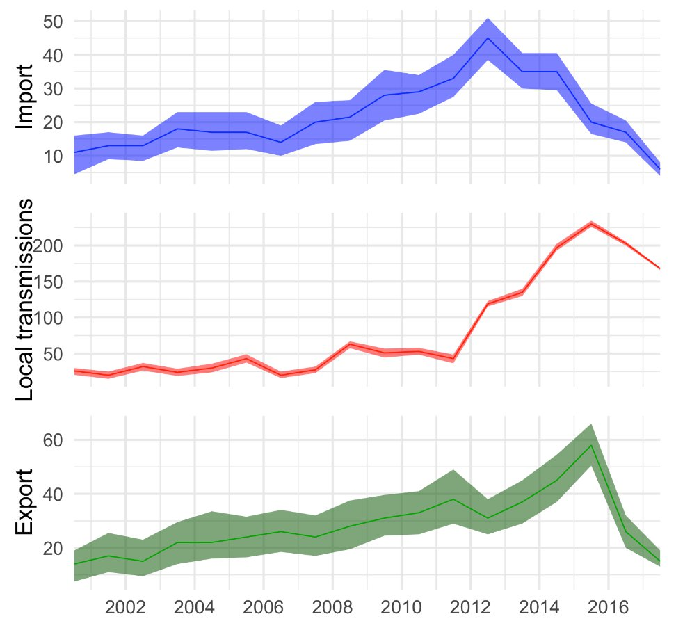

This page provides estimates of the total number of imports, exports and local transmissions in each location. Additionally we use the transmission lineages to derive how importation, exportation, and local transmission has varied in recent time.

### Growth rate of lineages and relation to metadata

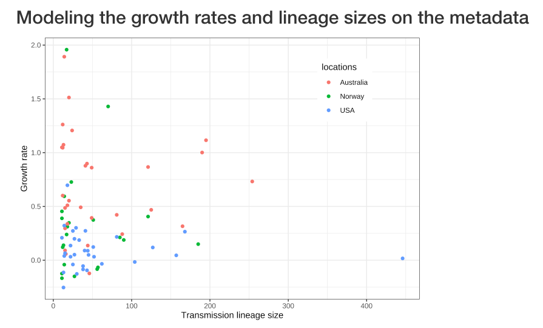

This page explores the relation of the growth rate of effective population size of the transmission lineages 2000-2017. We extract phylodynamic estimates of the growth rate TLs, and run regression analyses to estimate how location, gender distribution and the importation genes *penA* and *mtr* could have contributed to transmission lineage growth.

### Global metadata analysis

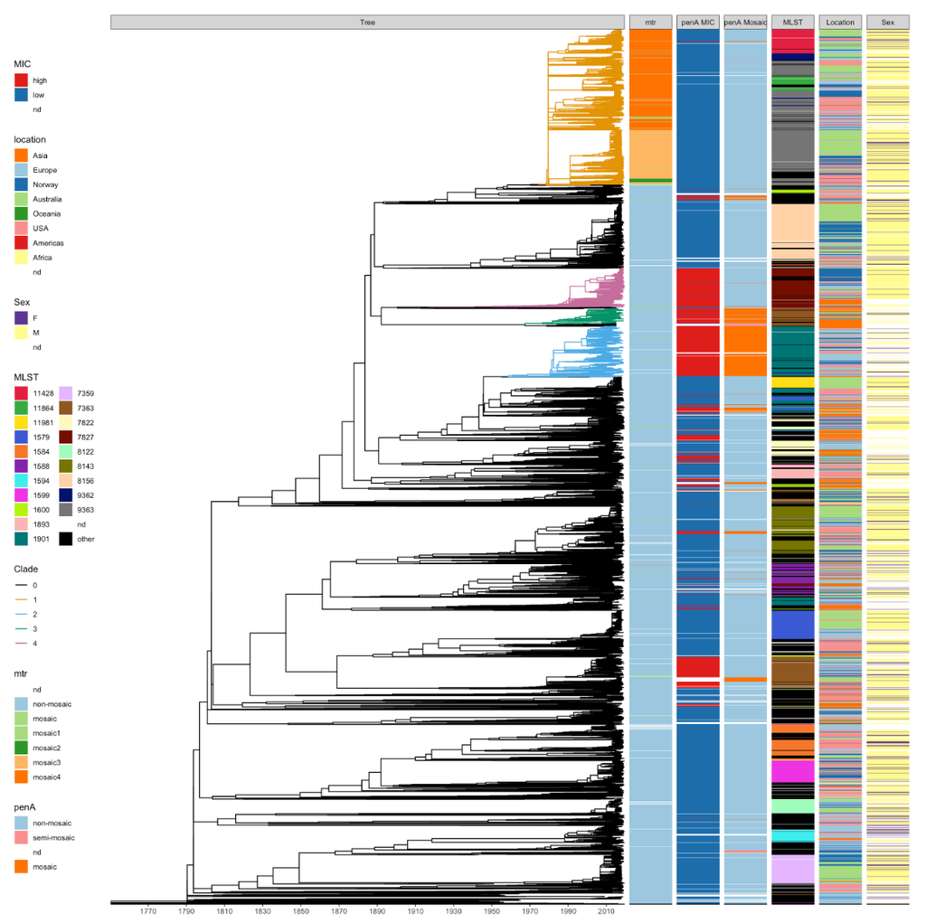

This page displays the full phylogenetic tree and associated metadata. Here we define important clades based on the observed metadata and phylogeny. The “important clades” display specific variants of the genes *mtr* and *penA* MIC category (high or low), which is known to be important for azitromycin and cephalosporin resistance. We estimate the effective population size dynamics to determine the growth of these clades in recent time.

### Investigating stability of estimates using downsampling

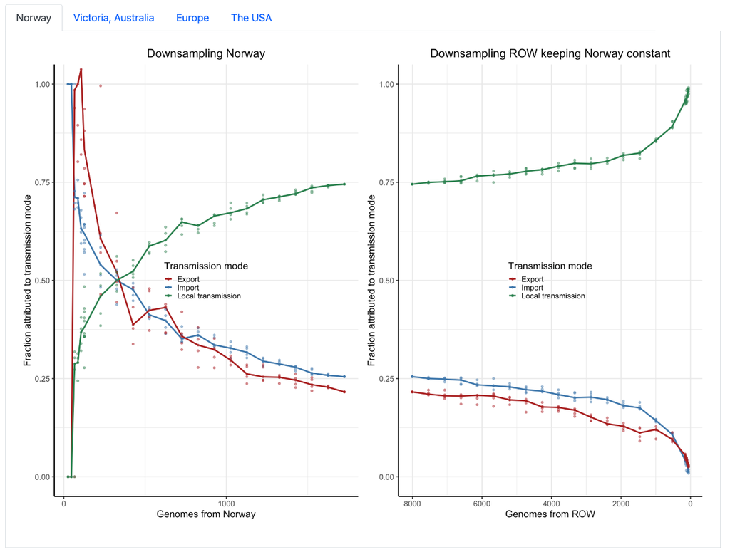

This page evaluates how reliable LineageHomology is in estimating import, export and local transmission of genomes in the different locations. It tests how the estimates changes in various scenarios of sampling density. The analysis focuses on the four locations: Norway, Victoria, Europe and the USA.